# Udemy Courses Analysis

## data source:

https://www.kaggle.com/datasets/andrewmvd/udemy-courses/data

# 1. Data Pre-processing and Exploration

## 1.1 Importing Libraries

```python
import pandas as pd
import numpy as np
import matplotlib.pyplot as plt
import seaborn as sns
import plotly.express as px
```

## 1.2 Loading and Inspecting the Data

```python
df = pd.read_csv("udemy_courses.csv")
df.head(3)
```

|  | course_id | course_title | url | is_paid | price | num_subscribers | num_reviews | num_lectures | level | content_duration | published_timestamp | subject |
| --- | --- | --- | --- | --- | --- | --- | --- | --- | --- | --- | --- | --- |
| 0 | 1070968 | Ultimate Investment Banking Course | https://www.udemy.com/ultimate-investment-bank... | True | 200 | 2147 | 23 | 51 | All Levels | 1.5 | 2017-01-18T20:58:58Z | Business Finance |
| 1 | 1113822 | Complete GST Course & Certification - Grow You... | https://www.udemy.com/goods-and-services-tax/ | True | 75 | 2792 | 923 | 274 | All Levels | 39.0 | 2017-03-09T16:34:20Z | Business Finance |
| 2 | 1006314 | Financial Modeling for Business Analysts and C... | https://www.udemy.com/financial-modeling-for-b... | True | 45 | 2174 | 74 | 51 | Intermediate Level | 2.5 | 2016-12-19T19:26:30Z | Business Finance |

1.3 Data Shape

```python
df.shape
# Output: (3678, 12)
```

```
(3678, 12)
```

1.4 Checking Missing Values

```python
df.isna().sum()
# Output indicates no missing values
```

```
course_id              0
course_title           0
url                    0
is_paid                0
price                  0
num_subscribers        0
num_reviews            0
num_lectures           0
level                  0
content_duration       0
published_timestamp    0
subject                0
dtype: int64
```

1.5 Checking for Duplicates

```python
df.duplicated().sum()
# Output: 6
```

```
6
```

```python
df.drop_duplicates(inplace=True)
df.duplicated().sum()
# Output: 0
```

```
0
```

1.6 Data Types and Statistical Summary

```python
df.info()
df.describe().round(2)
```

```
<class 'pandas.core.frame.DataFrame'>
Index: 3672 entries, 0 to 3677
Data columns (total 12 columns):
 #   Column               Non-Null Count  Dtype
---  ------               --------------  -----
 0   course_id            3672 non-null   int64
 1   course_title         3672 non-null   object
 2   url                  3672 non-null   object
 3   is_paid              3672 non-null   bool
 4   price                3672 non-null   int64
 5   num_subscribers      3672 non-null   int64
 6   num_reviews          3672 non-null   int64
 7   num_lectures         3672 non-null   int64
 8   level                3672 non-null   object
 9   content_duration     3672 non-null   float64
 10  published_timestamp  3672 non-null   object
 11  subject              3672 non-null   object
dtypes: bool(1), float64(1), int64(5), object(5)
memory usage: 347.8+ KB
```

|  | course_id | price | num_subscribers | num_reviews | num_lectures | content_duration |
| --- | --- | --- | --- | --- | --- | --- |
| count | 3672.00 | 3672.00 | 3672.00 | 3672.00 | 3672.00 | 3672.00 |
| mean | 675897.70 | 66.10 | 3190.59 | 156.37 | 40.14 | 4.10 |
| std | 343071.95 | 61.04 | 9488.11 | 936.18 | 50.42 | 6.06 |
| min | 8324.00 | 0.00 | 0.00 | 0.00 | 0.00 | 0.00 |
| 25% | 407761.50 | 20.00 | 111.75 | 4.00 | 15.00 | 1.00 |
| 50% | 687692.00 | 45.00 | 912.00 | 18.00 | 25.00 | 2.00 |
| 75% | 960814.00 | 95.00 | 2548.75 | 67.00 | 46.00 | 4.50 |
| max | 1282064.00 | 200.00 | 268923.00 | 27445.00 | 779.00 | 78.50 |

1.7 Value Counts for Categorical Variables

```python
df["subject"].value_counts()
```

```
subject
Web Development        1199
Business Finance       1191
Musical Instruments     680
Graphic Design          602
Name: count, dtype: int64
```

```python
df["level"].value_counts()
```

```
level
All Levels            1925
Beginner Level        1268
Intermediate Level     421
Expert Level            58
Name: count, dtype: int64
```

1.8 Converting and Extracting Date Information

```python
df['published_timestamp'] = pd.to_datetime(df['published_timestamp'])
df['year'] = df['published_timestamp'].dt.year
df['month'] = df['published_timestamp'].dt.month
df['quarter'] = df['published_timestamp'].dt.quarter
```

```python
df.sample(2)
```

|  | course_id | course_title | url | is_paid | price | num_subscribers | num_reviews | num_lectures | level | content_duration | published_timestamp | subject | year | month | quarter |
| --- | --- | --- | --- | --- | --- | --- | --- | --- | --- | --- | --- | --- | --- | --- | --- |
| 121 | 44836 | Option Spreads and Credit Spreads Bundle | https://www.udemy.com/option-spreads-and-credi... | True | 180 | 2212 | 194 | 24 | Expert Level | 4.5 | 2013-03-05 18:27:38+00:00 | Business Finance | 2013 | 3 | 1 |
| 1554 | 406054 | Photoshop: Real World Learning | https://www.udemy.com/photoshop-practical-trai... | True | 20 | 9 | 0 | 56 | All Levels | 5.0 | 2015-01-29 01:45:52+00:00 | Graphic Design | 2015 | 1 | 1 |

1.9 Add Profit and Price catogries columns

```python
df['year'].value_counts()
```

```
year
2016    1204
2015    1014
2017     713
2014     490
2013     201
2012      45
2011       5
Name: count, dtype: int64
```

```python
(df['price'] * df['num_subscribers'])
```

```
0       429400
1       209400
2        97830
3       232845
4       255200
         ...
3673    104000
3674      7650
3675     20520
3676     15000
3677     40545
Length: 3672, dtype: int64
```

```python
df['profit'] = (df['price'] * df['num_subscribers'])
```

```python
df.sample(2)
```

|  | course_id | course_title | url | is_paid | price | num_subscribers | num_reviews | num_lectures | level | content_duration | published_timestamp | subject | year | month | quarter | profit |
| --- | --- | --- | --- | --- | --- | --- | --- | --- | --- | --- | --- | --- | --- | --- | --- | --- |
| 2209 | 597868 | こどもギターレッスン リトルギタリストⅠ | https://www.udemy.com/takalittle1/ | True | 20 | 69 | 1 | 53 | Beginner Level | 3.000000 | 2015-11-07 23:09:05+00:00 | Musical Instruments | 2015 | 11 | 4 | 1380 |
| 992 | 75182 | Trade Show Samurai | https://www.udemy.com/trade-show-displays/ | True | 95 | 32 | 7 | 7 | All Levels | 0.516667 | 2013-08-29 15:44:46+00:00 | Business Finance | 2013 | 8 | 3 | 3040 |

```python
price_dict = {0:"Free",
              range(20,55,5):"20-50",
              range(55,105,5):"55-100",
              range(105,155,5):"105-150",
              range(155,205,5):"155-200"}
```

```python
df['price_category']=df["price"].replace(price_dict)
```

```python
df.head(2)
```

|  | course_id | course_title | url | is_paid | price | num_subscribers | num_reviews | num_lectures | level | content_duration | published_timestamp | subject | year | month | quarter | profit | price_category |
| --- | --- | --- | --- | --- | --- | --- | --- | --- | --- | --- | --- | --- | --- | --- | --- | --- | --- |
| 0 | 1070968 | Ultimate Investment Banking Course | https://www.udemy.com/ultimate-investment-bank... | True | 200 | 2147 | 23 | 51 | All Levels | 1.5 | 2017-01-18 20:58:58+00:00 | Business Finance | 2017 | 1 | 1 | 429400 | 155-200 |
| 1 | 1113822 | Complete GST Course & Certification - Grow You... | https://www.udemy.com/goods-and-services-tax/ | True | 75 | 2792 | 923 | 274 | All Levels | 39.0 | 2017-03-09 16:34:20+00:00 | Business Finance | 2017 | 3 | 1 | 209400 | 55-100 |

## 2. Insights and Visualizations

2.1 Course Distribution by Subject

```python
df['subject'].value_counts()
```

```
subject
Web Development        1199
Business Finance       1191
Musical Instruments     680
Graphic Design          602
Name: count, dtype: int64
```

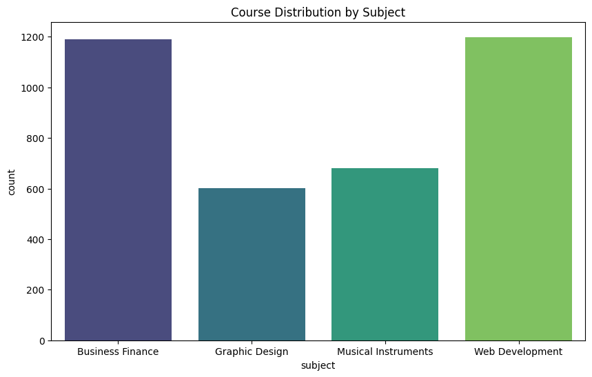

```python
plt.figure(figsize=(10, 6))
sns.countplot(data=df, x='subject', palette='viridis')
plt.title('Course Distribution by Subject')
plt.show()
```

2.2 Number of Courses by Level

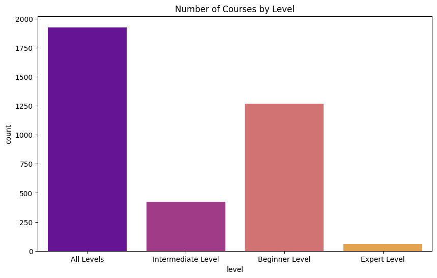

```python
plt.figure(figsize=(10, 6))
sns.countplot(data=df, x='level', palette='plasma')
plt.title('Number of Courses by Level')
plt.show()
```

2.3 Trend of Published Courses Over Time

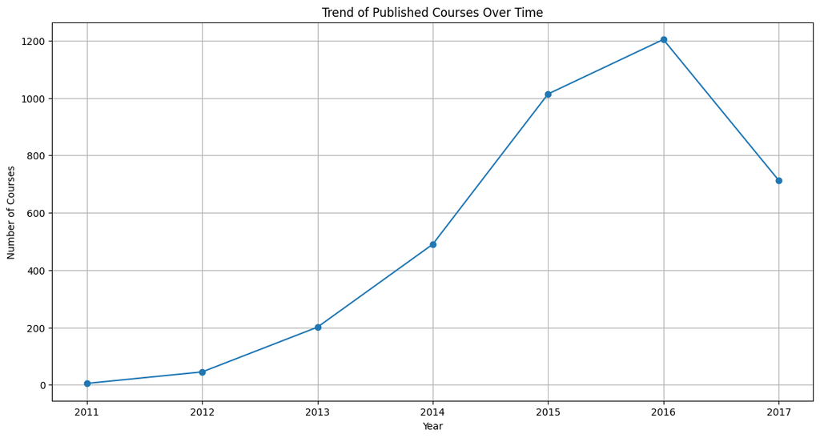

```python
plt.figure(figsize=(14, 7))
df.groupby('year').count()['course_id'].plot(kind='line', marker='o')
plt.title('Trend of Published Courses Over Time')
plt.xlabel('Year')
plt.ylabel('Number of Courses')
plt.grid(True)
plt.show()
```

2.4 Distribution of Free vs Paid Courses

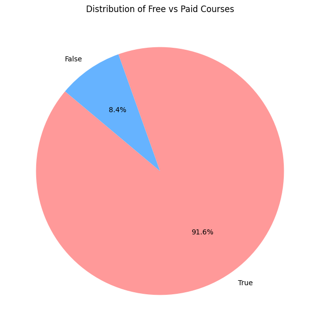

```python
labels = df['is_paid'].value_counts().index
sizes = df['is_paid'].value_counts().values
plt.figure(figsize=(8, 8))
plt.pie(sizes, labels=labels, autopct='%1.1f%%', startangle=140, colors=['#ff9999','#66b3ff'])
plt.title('Distribution of Free vs Paid Courses')
plt.show()
```

2.5 Top 10 Courses by Number of Subscribers

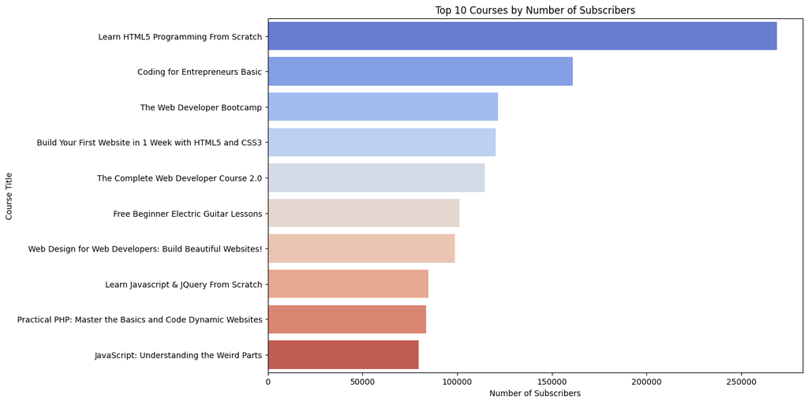

```python
top_courses = df.nlargest(10, 'num_subscribers')
plt.figure(figsize=(12, 8))
sns.barplot(data=top_courses, y='course_title', x='num_subscribers', palette='coolwarm')
plt.title('Top 10 Courses by Number of Subscribers')
plt.xlabel('Number of Subscribers')
plt.ylabel('Course Title')
plt.show()
```

2.6 Number of Subscribers by Subject

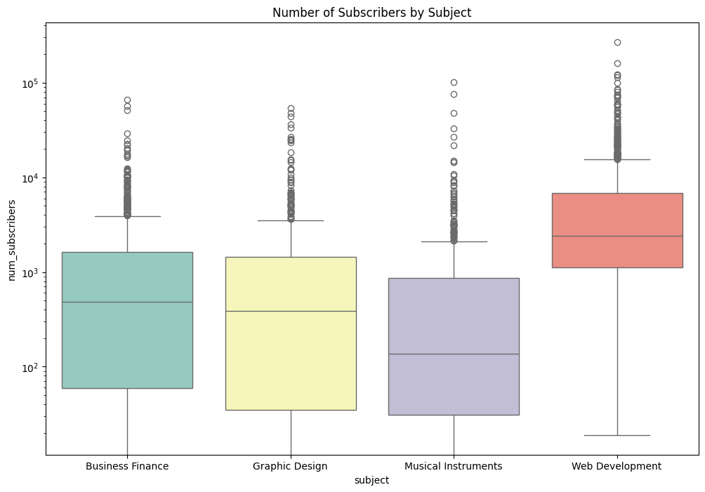

```python
plt.figure(figsize=(12, 8))
sns.boxplot(data=df, x='subject', y='num_subscribers', palette='Set3')
plt.yscale('log')
plt.title('Number of Subscribers by Subject')
plt.show()
```

2.7 Total Profit made by each subject

```python
df.groupby('subject',as_index=False)['profit'].sum().sort_values(by='profit',ascending=False)
```

|  | subject | profit |
| --- | --- | --- |
| 3 | Web Development | 627597400 |
| 0 | Business Finance | 123735315 |
| 1 | Graphic Design | 76983170 |
| 2 | Musical Instruments | 53359055 |

2.8 Number ofcourses in each subject with regard to price category

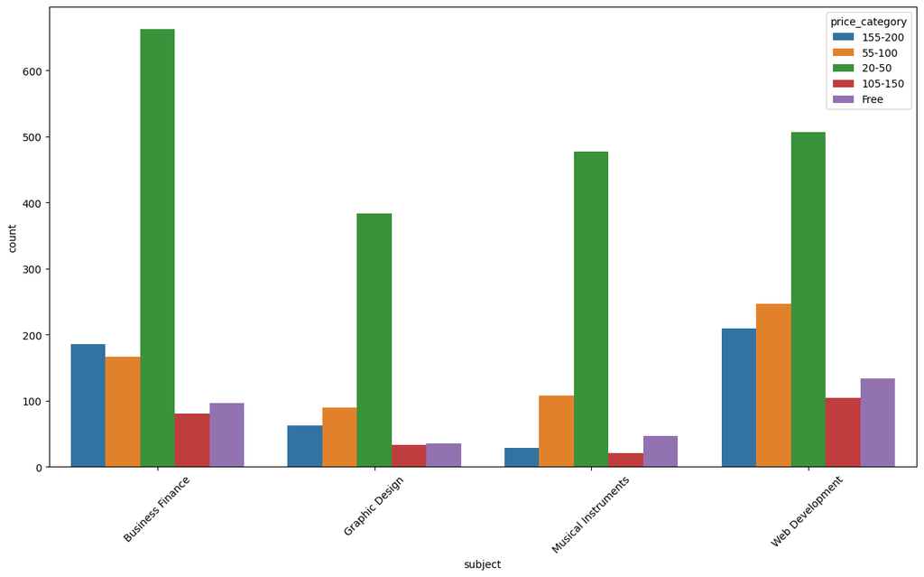

```python
plt.figure(figsize=(15,8))
plt.xticks(rotation=45)
sns.countplot(data=df, x=df['subject'],hue=df['price_category'])
```

2.9 Number of courses in each subject with regard to courses levels

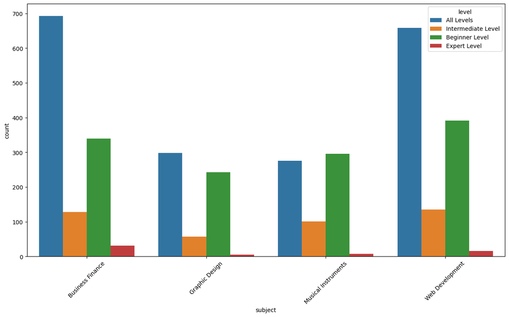

```python
plt.figure(figsize=(15,8))
plt.xticks(rotation=45)
sns.countplot(data=df, x=df['subject'],hue=df['level'])
```

## 3. Summry Script

3.1 Sales Summary Script

3.1.1 Calculate total sales

```python
total_sales = (df['num_subscribers'] * df['price']).sum()
print(f"Total Sales: ${total_sales:.2f}")
```

```
Total Sales: $881674940.00
```

3.1.2 Calculate average order value

```python
average_order_value = total_sales / len(df)
print(f"Average Order Value: ${average_order_value:.2f}")
```

```
Average Order Value: $240107.55
```

3.1.3 Find the most popular course

```python
most_popular_courses = df.groupby('course_title')['num_subscribers'].sum().idxmax()
print(f"Most Popular Course: {most_popular_courses}")
```

```
Most Popular Course: Learn HTML5 Programming From Scratch
```

3.2 Customer Behavior Analysis Script:

```python
top_customers = df.groupby('course_title')['num_subscribers'].sum().reset_index().nlargest(5, 'num_subscribers')
print(f"Top Courses:\n{top_customers}")
```

```
Top Courses:
                                           course_title  num_subscribers
2108               Learn HTML5 Programming From Scratch           268923
757                      Coding for Entrepreneurs Basic           161029
3296                         The Web Developer Bootcamp           121584
592   Build Your First Website in 1 Week with HTML5 ...           120291
3227              The Complete Web Developer Course 2.0           114512
```

3.2.2 analyze distribution of order frequencies

```python
order_frequencies = df['num_subscribers'].value_counts().tolist()
print(f"Order Frequencies:\n{order_frequencies}")
```

[output not shown]

3.3.3 giving insights into repeat customers

```python
repeat_customers = df[df.duplicated(subset='course_title', keep=False)]
print(f"Repeat Courses:\n{repeat_customers}")
```

```
Repeat Courses:
      course_id                                       course_title  \
1301     692920  Creating an animated greeting card via Google ...
1334     699376  Creating an animated greeting card via Google ...
1447     699380  Creating an animated greeting card via Google ...
2062      99324                      Acoustic Blues Guitar Lessons
2067     112314                      Acoustic Blues Guitar Lessons
2130     217628             Aprende a tocar el acordeón de botones
2158     647276                      Acoustic Blues Guitar Lessons
2332    1152334             Aprende a tocar el acordeón de botones
2375     818786                         Drum Lessons For Beginners
2445     210020                         Drum Lessons For Beginners
2607     178640                    Introduction to Web Development
2660      99986                    Introduction to Web Development
2806     674608  The Complete Web Developer Masterclass: Beginn...
```

[output cut: 75 more lines]

3.3 Product Popularity Script:

```python
best_selling_course = df.groupby('subject')['num_subscribers'].sum().reset_index().nlargest(3, 'num_subscribers')
```

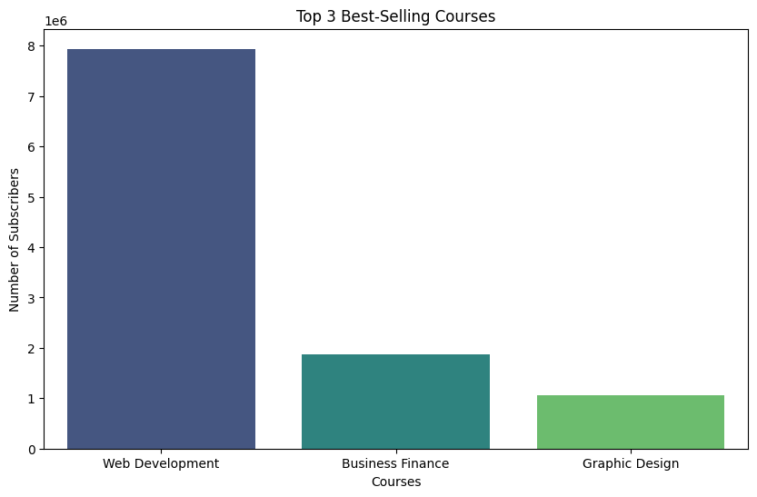

```python
plt.figure(figsize=(10, 6))
sns.barplot(x='subject', y='num_subscribers', data=best_selling_course, palette='viridis')
plt.xlabel('Courses')
plt.ylabel('Number of Subscribers')
plt.title('Top 3 Best-Selling Courses')
plt.show()
```